# Snake

Module code  
SSS

Skills required  
Algorithm writing  
R required

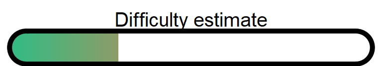

I’ve locked this module behind my favourite mobile game. You must beat the traditional game Snake with a point score of 50, 20 times in a row without failing.

Game rules: * Board size: 10 columns, 20 rows * Board edge is solid (you cannot go past the edge) * You cannot run into yourself * If you are unfamiliar with the game, ask me or watch this demo: https://youtu.be/NLCzNwva_CE.

You must write an R function that receives two inputs and outputs a direction key. The two inputs are: 1. Fruit position - the position of the ‘fruit’ the snake must eat. Numeric vector of length two, where v<sub>1</sub> is x-position (column) and v<sub>2</sub> is y-position (rows) in the grid. 2. Snake position - the position of the snake. A list of numeric vectors which each follow the same coordinate system as the fruit. The first element in the list is the snake’s head and the last is the snake’s tail.

The output must be a scalar variable that equals either: “U”/“D”/“L”/“R”, meaning Up/Down/Left/Right respectively.

Download the necessary files and read the documentation.